# Project_2

2023-10-22

The MASS package contains data on housing values in the city of Boston from the 1970s to the 1980s (data frame **Boston**). We are very interested in looking at how **the median home value (variable medv, measured in thousands of dollars) depends on various factors.**

The goal is to build a complete linear model, after standardizing the predictors. Interactions between the predictors do not need to be considered in the model.

Perform diagnostics of the model: a. Check the linearity of the relationships b. Check for influential observations c. Check the independence of observations d. Check for normality of the distribution and homoscedasticity (constant variance)

Create a prediction plot of home prices based on the variable with the largest coefficient by absolute value.

# 1 Data description

```r
library(MASS)
df <- as.data.frame(Boston)
str(df)
```

```
## 'data.frame':    506 obs. of  14 variables:
##  $ crim   : num  0.00632 0.02731 0.02729 0.03237 0.06905 ...
##  $ zn     : num  18 0 0 0 0 0 12.5 12.5 12.5 12.5 ...
##  $ indus  : num  2.31 7.07 7.07 2.18 2.18 2.18 7.87 7.87 7.87 7.87 ...
##  $ chas   : int  0 0 0 0 0 0 0 0 0 0 ...
##  $ nox    : num  0.538 0.469 0.469 0.458 0.458 0.458 0.524 0.524 0.524 0.524 ...
##  $ rm     : num  6.58 6.42 7.18 7 7.15 ...
##  $ age    : num  65.2 78.9 61.1 45.8 54.2 58.7 66.6 96.1 100 85.9 ...
##  $ dis    : num  4.09 4.97 4.97 6.06 6.06 ...
##  $ rad    : int  1 2 2 3 3 3 5 5 5 5 ...
##  $ tax    : num  296 242 242 222 222 222 311 311 311 311 ...
##  $ ptratio: num  15.3 17.8 17.8 18.7 18.7 18.7 15.2 15.2 15.2 15.2 ...
##  $ black  : num  397 397 393 395 397 ...
##  $ lstat  : num  4.98 9.14 4.03 2.94 5.33 ...
##  $ medv   : num  24 21.6 34.7 33.4 36.2 28.7 22.9 27.1 16.5 18.9 ...
```

This data frame contains the following columns:

- **crim** per capita crime rate by town.
- **zn** proportion of residential land zoned for lots over 25,000 sq.ft.
- **indus** proportion of non-retail business acres per town.
- **chas** Charles River dummy variable (= 1 if tract bounds river; 0 otherwise).
- **nox** nitrogen oxides concentration (parts per 10 million).
- **rm** average number of rooms per dwelling.
- **age** proportion of owner-occupied units built prior to 1940.
- **dis** weighted mean of distances to five Boston employment centres.
- **rad** index of accessibility to radial highways.
- **tax** full-value property-tax rate per $10,000.
- **ptratio** pupil-teacher ratio by town.
- **black** proportion of blacks by town
- **lstat** lower status of the population (percent).
- **medv** median value of owner-occupied homes in $1000s.

# 2 Building the Complete Linear Model

First, we will standardize the variables. At this initial stage, we will not consider the interaction between the predictors.

```r
df_standartized <-  as.data.frame(sapply(df[-4], scale))
df_standartized$chas <- as.factor(df$chas)
df_standartized$chas <-  relevel(df_standartized$chas, ref = '0')
```

Now let’s build a model:

```r
full_model <- lm(medv ~ ., data = df_standartized)
summary(full_model)
```

```
##
## Call:
## lm(formula = medv ~ ., data = df_standartized)
##
## Residuals:
##      Min       1Q   Median       3Q      Max
## -1.69559 -0.29680 -0.05633  0.19322  2.84864
##
## Coefficients:
##              Estimate Std. Error t value Pr(>|t|)
## (Intercept) -0.020206   0.023835  -0.848 0.396976
## crim        -0.101017   0.030737  -3.287 0.001087 **
## zn           0.117715   0.034811   3.382 0.000778 ***
## indus        0.015335   0.045871   0.334 0.738288
## nox         -0.223848   0.048126  -4.651 4.25e-06 ***
## rm           0.291056   0.031928   9.116  < 2e-16 ***
## age          0.002119   0.040430   0.052 0.958229
## dis         -0.337836   0.045666  -7.398 6.01e-13 ***
## rad          0.289749   0.062813   4.613 5.07e-06 ***
## tax         -0.226032   0.068912  -3.280 0.001112 **
## ptratio     -0.224271   0.030796  -7.283 1.31e-12 ***
## black        0.092432   0.026662   3.467 0.000573 ***
## lstat       -0.407447   0.039378 -10.347  < 2e-16 ***
## chas1        0.292128   0.093679   3.118 0.001925 **
## ---
## Signif. codes:  0 '***' 0.001 '**' 0.01 '*' 0.05 '.' 0.1 ' ' 1
##
## Residual standard error: 0.516 on 492 degrees of freedom
## Multiple R-squared:  0.7406, Adjusted R-squared:  0.7338
## F-statistic: 108.1 on 13 and 492 DF,  p-value: < 2.2e-16
```

# 3 Model Diagnostics

## 3.1 Check for normality of the distribution and homoscedasticity (constant variance)

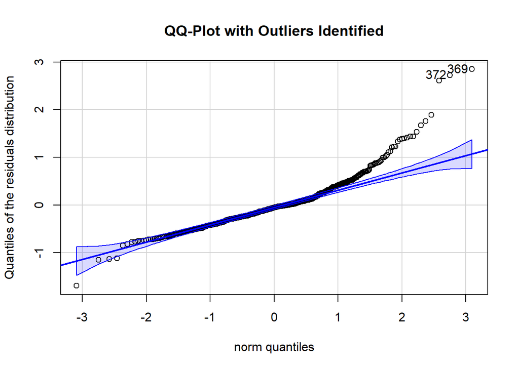

```
## [1] 369 372
```

```r
qqPlot(residuals(full_model), main = "QQ-Plot with Outliers Identified", ylab = 'Quantiles of the residuals distribution')
```

The quantile plot does not look very good; it cannot be said that the standardized residuals are normally distributed.

## 3.2 Check the independence of observations

If we look at the structure of the dataset, we can notice the presence of correlations between the predictors. Therefore, checking for multicollinearity is especially relevant in this case.

One way to check the model for multicollinearity of the predictors is to use VIF (Variance Inflation Factor).

If a predictor has a VIF value greater than 2, it should be excluded from the model.

If there are several such predictors, a stepwise algorithm is applied: calculate the VIF, remove the predictor with the highest VIF, recalculate the VIF for the updated model, and repeat until all values are below the threshold.

```r
vif(full_model)
```

```
##     crim       zn    indus      nox       rm      age      dis      rad
## 1.792192 2.298758 3.991596 4.393720 1.933744 3.100826 3.955945 7.484496
##      tax  ptratio    black    lstat     chas
## 9.008554 1.799084 1.348521 2.941491 1.073995
```

In this case, we can easily observe the presence of multicollinearity in our model. Some predictors will need to be removed from the model in further steps.

## 3.3 Check the linearity of relationships

The residuals distribution plot does not look very good. A fairly large number of observations are beyond two standard deviations, and a clear pattern is visible in the residuals. All of this indicates the presence of nonlinearity in the relationship as well as heteroscedasticity (non-constant variance).

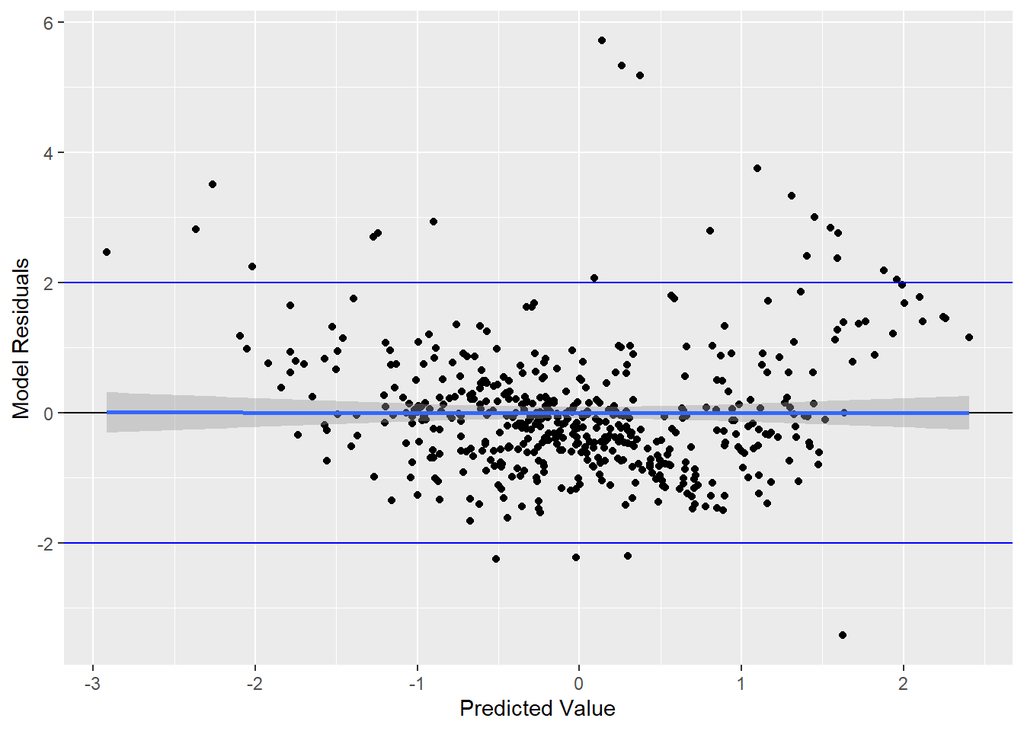

```r
gg_resid <- ggplot(data = full_model, aes(x = .fitted, y = .stdresid)) +
  geom_point() +
  geom_hline(yintercept = 0) +
  geom_smooth(method = "lm") +
  geom_hline(yintercept = 2, color = "blue") +
  geom_hline(yintercept = -2, color = "blue") +
  xlab('Predicted Value') +
  ylab('Model Residuals')
gg_resid
```

## 3.4 Check for influential observations

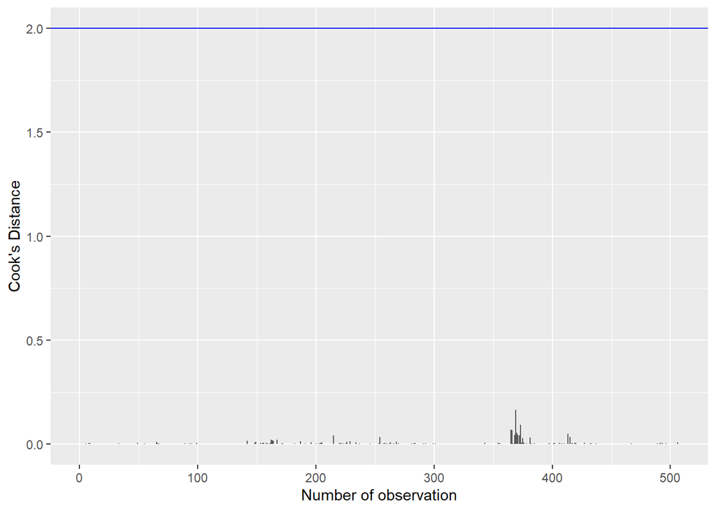

```r
cooksd <- cooks.distance(full_model)

# Create a data frame for plotting
mod_full_diag <- data.frame(observation = 1:length(cooksd), cooksd = cooksd)

# Plot Cook's distances using ggplot
ggplot(mod_full_diag, aes(x = observation, y = cooksd)) +
  geom_bar(stat = "identity") +
  geom_hline(yintercept = 2, color = "blue") +
  xlab('Number of observation') +
  ylab('Cook\'s Distance')
```

None of the values exceed the conventional threshold of 2 units. There are no influential observations.

# 4 Model Predictions

We will plot the predicted values of house prices based on the variable with the largest absolute coefficient. In this case, it is the variable lstat.

We cannot account for the variability of all predictors at once. Therefore, we usually choose one that interests us the most (in our case, lstat). Based on this, a test dataset is created, where the target predictor takes values from the minimum to the maximum, while all other predictors are represented by their mean values.

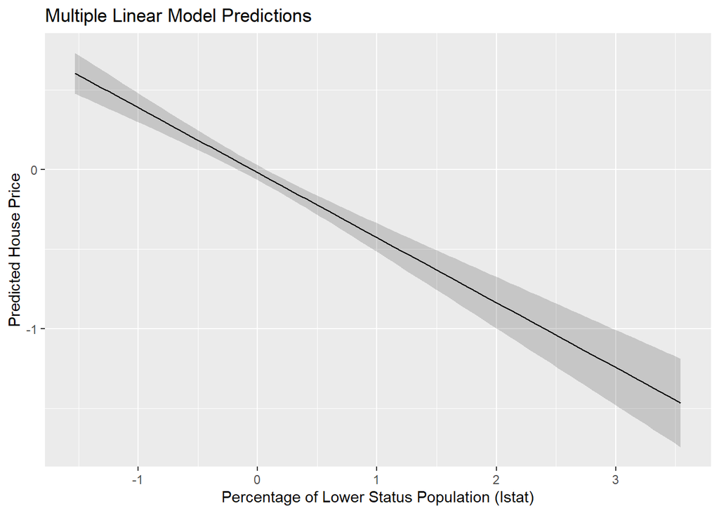

```r
test_data <- data.frame(
  lstat = seq(min(df_standartized$lstat), max(df_standartized$lstat), length.out = 90),
  crim = rep(mean(df_standartized$crim), 90),
  zn = rep(mean(df_standartized$zn), 90),
  indus = rep(mean(df_standartized$indus), 90),
  nox = rep(mean(df_standartized$nox), 90),
  rm = rep(mean(df_standartized$rm), 90),
  age = rep(mean(df_standartized$age), 90),
  dis = rep(mean(df_standartized$dis), 90),
  rad = rep(mean(df_standartized$rad), 90),
  tax = rep(mean(df_standartized$tax), 90),
  ptratio = rep(mean(df_standartized$ptratio), 90),
  black = rep(mean(df_standartized$black), 90),
  chas = rep('0', 90)  # assuming 'chas' is a categorical variable
)

Predictions <- predict(full_model, newdata = test_data, interval = 'confidence')
MyData <- data.frame(test_data, Predictions)

Pl_predict <- ggplot(MyData, aes(x = lstat, y = fit)) +
  geom_ribbon(alpha = 0.2, aes(ymin = lwr, ymax = upr)) +
  geom_line() +
  ggtitle("Multiple Linear Model Predictions") +
  xlab('Percentage of Lower Status Population (lstat)') +
  ylab('Predicted House Price')
Pl_predict
```

# 5 Additional Section

Let’s return to our full model and recall the results of the multicollinearity check.

```r
vif(full_model)
```

```
##     crim       zn    indus      nox       rm      age      dis      rad
## 1.792192 2.298758 3.991596 4.393720 1.933744 3.100826 3.955945 7.484496
##      tax  ptratio    black    lstat     chas
## 9.008554 1.799084 1.348521 2.941491 1.073995
```

We will iteratively remove one predictor with the highest VIF from the model until all values are below the threshold (2).

```r
mod2 <- update(full_model, .~. - tax)
#vif(mod2)

mod3 <- update(mod2, .~. - nox)
#vif(mod3)

mod4 <- update(mod3, .~. - dis)
#vif(mod4)

mod5 <- update(mod4, .~. - lstat)
#vif(mod5)

mod6 <- update(mod5, .~. - nox)
#vif(mod6)

mod7 <- update(mod6, .~. - rad)
#vif(mod7)

mod_good <- update(mod7, .~. - indus)
vif(mod_good)
```

```
##     crim       zn       rm      age  ptratio    black     chas
## 1.342583 1.680416 1.216701 1.668190 1.345528 1.209887 1.043732
```

The final model at this stage

When the categorical variable chas equals 1: medv = -3.54 - 0.11 * crim - 0.003 * zn + 7.06 * rm - 0.04 * age - 0.93 * ptratio + 0.015 * black

## Step 1: Finding the Optimal Model

We can leave the model in this form, or we can try to retain only the predictors that significantly affect the house prices (a large number of predictors usually leads to overfitting).

### 5.1.1 Stepwise Selection of Predictors by Significance

In this work, I will use the backward selection (also known as backward elimination) algorithm for predictor selection. As a selection criterion, I will use the partial F-test.

```r
drop1(mod_good , test = 'F')
```

```
## Single term deletions
##
## Model:
## medv ~ crim + zn + rm + age + ptratio + black + chas
##         Df Sum of Sq    RSS     AIC  F value    Pr(>F)
## <none>               183.35 -497.65
## crim     1     3.821 187.17 -489.22  10.3772 0.0013592 **
## zn       1     0.019 183.37 -499.60   0.0506 0.8220598
## rm       1   120.885 304.24 -243.42 328.3350 < 2.2e-16 ***
## age      1     4.869 188.22 -486.39  13.2258 0.0003049 ***
## ptratio  1    17.907 201.26 -452.50  48.6365 9.843e-12 ***
## black    1     9.234 192.59 -474.79  25.0805 7.646e-07 ***
## chas     1     4.573 187.93 -487.19  12.4206 0.0004638 ***
## ---
## Signif. codes:  0 '***' 0.001 '**' 0.01 '*' 0.05 '.' 0.1 ' ' 1
```

```r
mod_good_unstd <- update(mod_good, .~. - zn)
drop1(mod_good_unstd, test = 'F')
```

```
## Single term deletions
##
## Model:
## medv ~ crim + rm + age + ptratio + black + chas
##         Df Sum of Sq    RSS     AIC F value    Pr(>F)
## <none>               183.37 -499.60
## crim     1     3.892 187.26 -490.98  10.591 0.0012133 **
## rm       1   123.107 306.48 -241.70 335.006 < 2.2e-16 ***
## age      1     6.083 189.45 -485.09  16.553 5.498e-05 ***
## ptratio  1    18.978 202.35 -451.77  51.644 2.440e-12 ***
## black    1     9.225 192.59 -476.77  25.103 7.559e-07 ***
## chas     1     4.611 187.98 -489.04  12.546 0.0004342 ***
## ---
## Signif. codes:  0 '***' 0.001 '**' 0.01 '*' 0.05 '.' 0.1 ' ' 1
```

Thus, we kept only the predictors with a significant influence on the dependent variable ( **crim**, **rm**, **age**, **ptratio**, **black**, **chas**.

```r
summary(mod_good_unstd)
```

```
##
## Call:
## lm(formula = medv ~ crim + rm + age + ptratio + black + chas,
##     data = df_standartized)
##
## Residuals:
##     Min      1Q  Median      3Q     Max
## -2.1005 -0.3188 -0.0811  0.1863  4.3171
##
## Coefficients:
##             Estimate Std. Error t value Pr(>|t|)
## (Intercept) -0.02655    0.02797  -0.949 0.342916
## crim        -0.10137    0.03115  -3.254 0.001213 **
## rm           0.53869    0.02943  18.303  < 2e-16 ***
## age         -0.12292    0.03021  -4.069 5.50e-05 ***
## ptratio     -0.21653    0.03013  -7.186 2.44e-12 ***
## black        0.14865    0.02967   5.010 7.56e-07 ***
## chas1        0.38390    0.10838   3.542 0.000434 ***
## ---
## Signif. codes:  0 '***' 0.001 '**' 0.01 '*' 0.05 '.' 0.1 ' ' 1
##
## Residual standard error: 0.6062 on 499 degrees of freedom
## Multiple R-squared:  0.6369, Adjusted R-squared:  0.6325
## F-statistic: 145.9 on 6 and 499 DF,  p-value: < 2.2e-16
```

### 5.1.2 Model Diagnostics

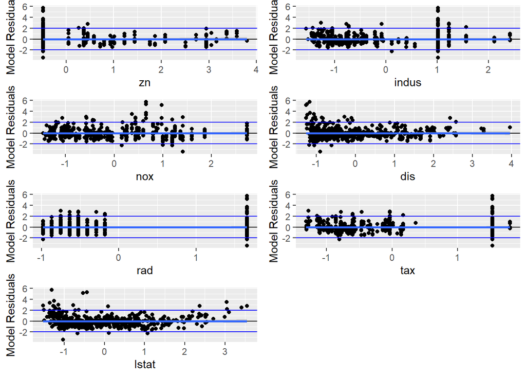

```r
res1 <- gg_resid + aes(x = zn)
res2 <- gg_resid + aes(x = indus)
res3 <- gg_resid + aes(x = nox)
res4 <- gg_resid + aes(x = dis)
res5 <- gg_resid + aes(x = rad)
res6 <- gg_resid + aes(x = tax)
res7 <- gg_resid + aes(x = lstat)
grid.arrange(res1, res2, res3, res4, res5, res6, res7, nrow = 4)
```

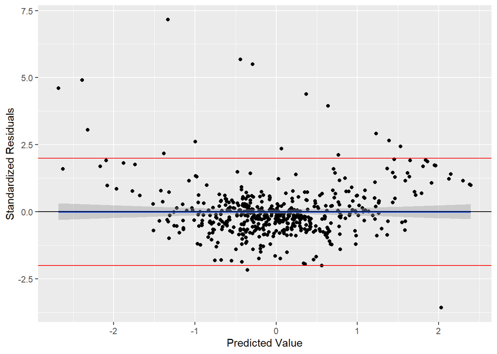

```r
gg_resid <- ggplot(data = mod_good_unstd, aes(x = .fitted, y = .stdresid)) +
  geom_point() +
  geom_smooth(method = "lm") +
  geom_hline(yintercept = 0) +
  geom_hline(yintercept = 2, color = "red") +
  geom_hline(yintercept = -2, color = "red") +
  xlab('Predicted Value') +
  ylab('Standardized Residuals')

gg_resid
```

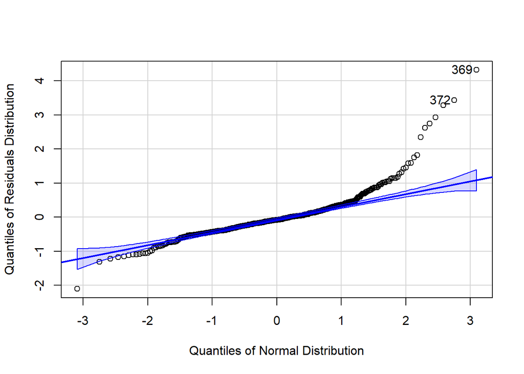

```
## [1] 369 372
```

```r
qqPlot(residuals(mod_good_unstd), xlab = 'Quantiles of Normal Distribution', ylab = 'Quantiles of Residuals Distribution')
```

The analysis showed that if any issues were corrected, it wasn’t very effective. The model is far from perfect. In this case, some transformation of variables might have helped (though this is often undesirable as it complicates the interpretation of results), or the use of other statistical methods, which will likely be discussed in future projects. Additionally, attempts to account for interactions between variables within the final model did not lead to success; in fact, the Cook’s distance plot became worse (not shown here). At a first approximation, we can try to predict which aspects need improvement to maximize the price of a house.

## 5.2 Customer recomendations

Finall model is:

When the categorical variable chas = 1: medv = -3.54 - 0.11 * crim + 7.05 * rm - 0.04 * age - 0.92 * ptratio + 0.015 * black

We can see 6 parameters that, in one way or another, influence house prices. Here are some insights that, in my opinion, should help maximize the price of a house for sale:

Thus, in the ideal neighborhood:

- Properties border a river.
- Low crime rate.
- A large number of rooms in houses (up to 8 in this case, as the data does not show higher values).
- It would be ideal if the number of students per class were minimal, for example, three.
- The approximate house price under these conditions could be $50.1K.